# Does Martingle strategy really work in Roulette?

Can Luo

9/15/2019

A roulette table composed of 38 (or 37) evenly sized pockets on a wheel. The pockets are colored red, black, or green. The pockets are also numbered. Roulette is a game of chance in which a pocket is randomly selected. Gamblers may wager on several aspects of the outcome. For example, one may place a wager that the randomly selected pocket will be red or odd numbered or will be a specific number.

In this blog, we note that there are 38 pockets of which 2 are green, 18 are red, and 18 are black. The payout for a bet on black (or red) is $1 for each $1 wagered. This means that if a gambler bets $1 on black and the randomly selected pocket is black, then the gambler will get the original $1 wager and an additional $1 as winnings.

There are lots of strategies about roulette. And what we focus on is the Martingale strategy(https://github.com/thomasgstewart/data-science-5620/blob/master/deliverables/01-roulette.md), which appears to always end in positive earnings, regardless of how unlucky a string of spins may be. Is the strategy actually profitable?

Now let computer simulation tell us the truth.

# I Function Parts

| Summary of parameters |
| --- |

| Parameter | Description | Starting value |
| --- | --- | --- |
| **B** | Starting budget | $200 |
| **W** | Winnings threshold for stopping | $300 (Starting budget + $100 winnings) |
| **L** | Time threshold for stopping | 1000 plays |
| **M** | Casino’s maximum wager | $100 |

Basically we need these functions below.

```r
library(dplyr)
one_play <- function(state){


    proposed_wager <- ifelse(state$previous_win, 1, 2*state$previous_wager)
    wager <- min(proposed_wager, state$M, state$B)


    red <- rbinom(1,1,18/38)


    state$plays <- state$plays + 1
    state$previous_wager <- wager
    if(red){

      state$B <- state$B + wager
      state$previous_win <- TRUE
    }else{

      state$B <- state$B - wager
      state$previous_win <- FALSE
    }
  state
}



stop_play <- function(state){
  if(state$B <= 0) return(TRUE)
  if(state$plays >= state$L) return(TRUE)
  if(state$B >= state$W) return(TRUE)
  FALSE
}



one_series <- function(
    B = 200
  , W = 300
  , L = 1000
  , M = 100
){

  # initial state
  state <- list(
    B = B
  , W = W
  , L = L
  , M = M
  , plays = 0
  , previous_wager = 0
  , previous_win = TRUE
  )


  budget <- rep(NA, L)


  for(i in 1:L){
    new_state <- state %>% one_play
    budget[i] <- new_state$B
    if(new_state %>% stop_play){
      return(budget[1:i])
    }
    state <- new_state
  }
  budget
}
get_last <- function(x) x[length(x)]
```

# II One Single Simulation

Then let’s do one simulation,which will show how the gamblers earnings (or losses) evolve over a series of wagers at the roulette wheel. (The x-axis will be the wager number (or play number), the y-axis will be earnings.)

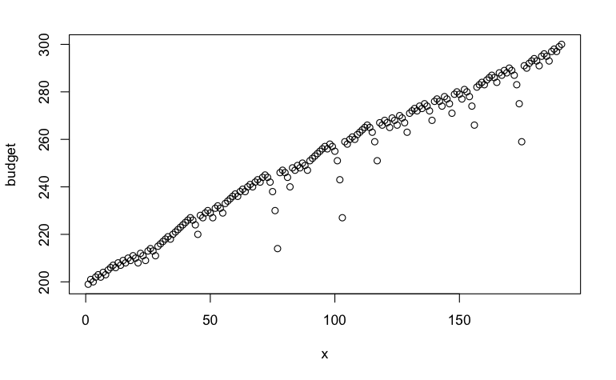

```r
budget<-one_series(B = 200, W = 300, L = 1000, M = 100)
x<-c(1:length(budget))
plot(x,budget)
```

Let’s see if the simulation repeats 1000 times, how the walk-out money distributes.

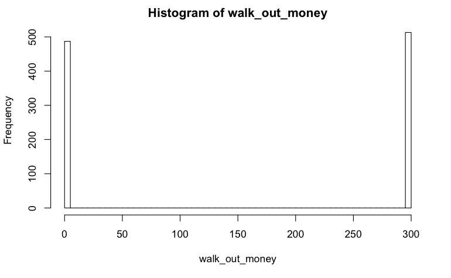

```r
walk_out_money <- rep(NA, 1000)
for(j in seq_along(walk_out_money)){
  walk_out_money[j] <- one_series(B = 200, W = 300, L = 1000, M = 100) %>% get_last
}


hist(walk_out_money, breaks = 100)
```

# III Numbers of play

Since there are 3 stopping rules below:

A player will use the above strategy and play until 1.the player has W dollars 2.the player goes bankrupt 3.the player completes L wagers (or plays)

The simulation will stop according to the rules and the distribution of number of plays in amounts of simulation is as follows.

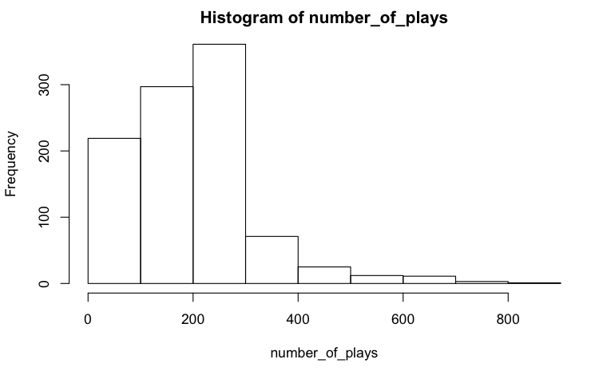

```r
number_of_plays <- rep(NA, 1000)
for(j in seq_along(number_of_plays)){
  number_of_plays[j] <-one_series(B = 200, W = 300, L = 1000, M = 100) %>%length
}


hist(number_of_plays,breaks=10)
```